# Project 2: Data Mining, Classification, Prediction

## Introduction

The dataset is from Rossi et al. (1980) and investigates criminal recidivism. 432 convicts were followed up one year after release. The data includes the numeric variables of week of arrest, age, number of prior convictions, and education level. The binary variables include whether they were arrested, received financial aid, had prior work experience, were black, were married, released on parole, and job status per week. The main binary variable I will be looking at is whether they were arrested and in the dataset, 318 people were not arrested while 114 were arrested again.

```r
library(tidyverse)
library(dplyr)
library(readr)
Rossi <- read_csv("Rossi.csv")
Rossi$employment <- rowSums(Rossi[, 12:63] == "yes", na.rm = T)
Rossi <- Rossi %>%
    select(-(12:63))
Rossi %>%
    group_by(arrest) %>%
    summarize(n())
```

```
## # A tibble: 2 x 2
##   arrest `n()`
##    <dbl> <int>
## 1      0   318
## 2      1   114
```

Additionally, I tidied the dataset by aggregating the job status per week into total weeks of employment. Also, if the person was not arrested again, their week of arrest is listed at 52 weeks.

## Cluster Analysis

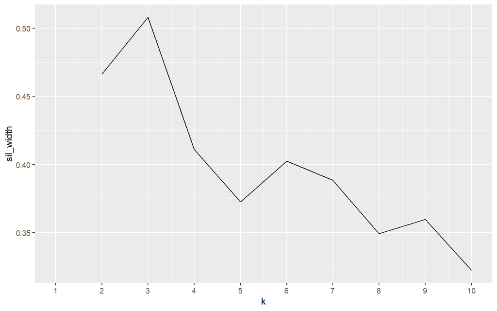

```r
library(cluster)
library(GGally)

RossiNum <- Rossi %>%
    select(week, age, prio, educ, employment)

sil_width <- vector()
for (i in 2:10) {
    kms <- kmeans(RossiNum, centers = i)
    sil <- silhouette(kms$cluster, dist(RossiNum))
    sil_width[i] <- mean(sil[, 3])
}
ggplot() + geom_line(aes(x = 1:10, y = sil_width)) + scale_x_continuous(name = "k",
    breaks = 1:10)
```

[figure not shown]

```r
# 3 clusters
pam1 <- RossiNum %>%
    pam(k = 3)
plot(pam1, which = 2, border = NA, col = "red")
```

```r
# Average sil width is .5 which is weak and could be
# artificial.
RossiPam <- RossiNum %>%
    pam(3)
RossiPam
```

```
## Medoids:
##       ID week age prio educ employment
## [1,] 357   19  22    4    3          1
## [2,] 340   52  26    2    3         40
## [3,] 194   52  22    2    3          8
## Clustering vector:
##   [1] 1 1 1 2 2 3 1 3 3 3 3 2 3 2 1 2 1 3 2 3 3 2 1 2 3 2 2 3 2 2 3 2 2 3 2 2 2
##  [38] 3 3 3 2 3 1 2 3 2 3 1 2 2 2 3 2 2 2 3 2 2 2 2 1 3 3 3 3 2 2 3 3 3 3 3 2 2
##  [75] 2 2 3 2 3 1 1 3 3 3 1 3 3 1 3 2 2 3 2 2 3 1 2 3 3 2
##  [ reached getOption("max.print") -- omitted 332 entries ]
## Objective function:
##    build     swap
## 11.52252 10.58172
##
## Available components:
##  [1] "medoids"    "id.med"     "clustering" "objective"  "isolation"
##  [6] "clusinfo"   "silinfo"    "diss"       "call"       "data"
```

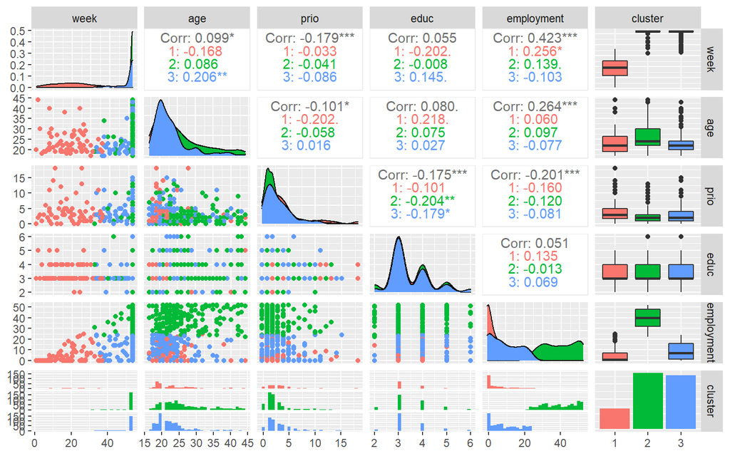

```r
RossiNum %>%
    mutate(cluster = as.factor(pam1$clustering)) %>%
    ggpairs(aes(color = cluster))
```

I examined the numerical variables of week arrested, age, prior convictions, education level, and total weeks of employment. I computed the k-means solution for each potential number of clusters in order to find the highest silhouette width since a higher width means the clusters more cohesive and separated. I found that 3 clusters had the highest silhouette width; however, the 3-cluster solution had a silhouette width of .5 which is weak and could be artificial. The first cluster had an early arrest and less weeks of employment. The second cluster had a late/no arrest, higher age range, and more weeks of employment. The third cluster had a late/no arrest and less weeks of employment.